# Lab6Submission

Author

Sean Kim

```r
library(dplyr)
library(data.table)
library(tidyverse)
library(tidytext)
library(ggplot2)

medscript_raw <- fread("https://raw.githubusercontent.com/USCbiostats/data-science-data/master/00_mtsamples/mtsamples.csv")
```

## **Question 1: What specialties do we have?**

```r
new_column_names <- c("EntryID", "Description", "MedicalSpecialty", "SampleName", "TranscriptionSubjective", "Keywords")

medscript_raw <- rename(medscript_raw, !!!setNames(names(medscript_raw), new_column_names))

num_categories <- medscript_raw %>%
  count(MedicalSpecialty, sort = TRUE)
num_categories
```

```
                 MedicalSpecialty    n
 1:                       Surgery 1103
 2:    Consult - History and Phy.  516
 3:    Cardiovascular / Pulmonary  372
 4:                    Orthopedic  355
 5:                     Radiology  273
 6:              General Medicine  259
 7:              Gastroenterology  230
 8:                     Neurology  223
 9: SOAP / Chart / Progress Notes  166
10:       Obstetrics / Gynecology  160
11:                       Urology  158
12:             Discharge Summary  108
13:          ENT - Otolaryngology   98
14:                  Neurosurgery   94
```

[output cut: 28 more lines]

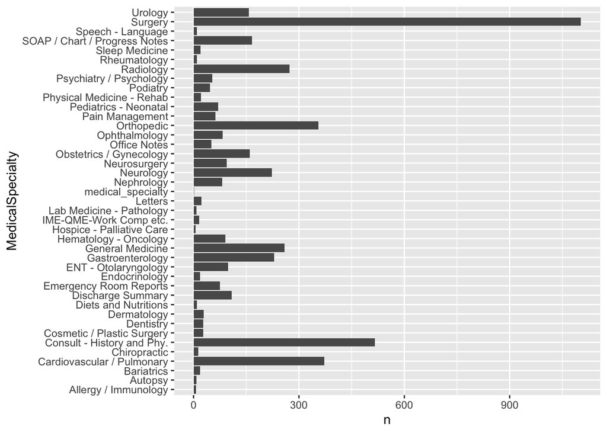

```r
columnSpec <-ggplot(num_categories, aes(x = MedicalSpecialty, y = n)) +
  geom_col()

columnSpec + coord_flip()
```

## Question 2: Tokenize

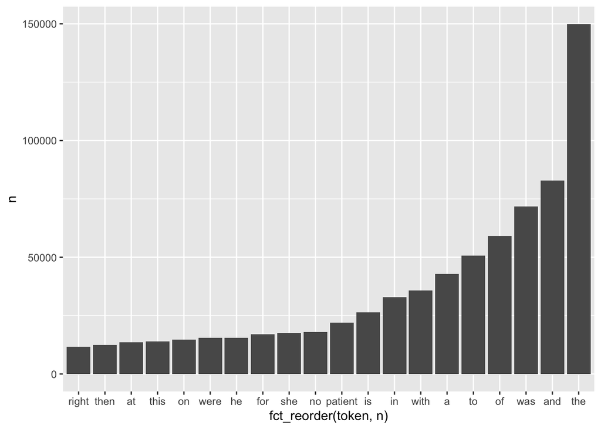

```r
medscript_char <- medscript_raw%>%
  select(2:6) %>%
  unnest_tokens(token, TranscriptionSubjective) %>%
  count(token, sort = TRUE) %>%
  top_n(20, n)

PlotTokens <- ggplot(medscript_char, aes(n, fct_reorder(token, n))) +
  geom_col()

PlotTokens + coord_flip()
```

## Question 3: Remove Stopwords

```r
stop_words
```

```
# A tibble: 1,149 × 2
   word        lexicon
   <chr>       <chr>
 1 a           SMART
 2 a's         SMART
 3 able        SMART
 4 about       SMART
 5 above       SMART
 6 according   SMART
 7 accordingly SMART
 8 across      SMART
 9 actually    SMART
10 after       SMART
# ℹ 1,139 more rows
```

```r
Medscript <- medscript_raw %>%
  unnest_tokens(token, TranscriptionSubjective) %>%
  filter(!str_detect(token, "\\d+")) %>%
  anti_join(stop_words, by = c("token" = "word")) %>%
  count(token, sort = TRUE)
Medscript
```

```
             token     n
    1:     patient 22065
    2:        left 11258
    3:     history  9509
    4:      normal  7526
    5:   procedure  7463
   ---
20599:   worthless     1
20600:   wristband     1
20601:       xyzal     1
20602: zithromycin     1
20603:        zung     1
```

After getting rid of numbers and stop_words, the remaining frequently used terms are definitely more medically related, however some still don’t give much information (patient, normal, procedure, noted, time).

## Question 4 - Bi-grams and Tri-grams

```r
medscript_bigram <- medscript_raw %>%
  unnest_tokens(ngram, TranscriptionSubjective, token = "ngrams", n = 2) %>%
  separate(ngram, into = c("word1", "word2"), sep = " ") %>%
  select(word1, word2) %>%
  count(word1, word2, sort = TRUE)%>%
  top_n(20, n)

medscript_bigram
```

```
     word1   word2     n
1      the patient 20307
2       of     the 19062
3       in     the 12790
4       to     the 12374
5      was    then  6956
6      and     the  6350
7  patient     was  6293
8      the   right  5509
9       on     the  5241
10     the    left  4860
11    with       a  4857
12 history      of  4537
13      to      be  4345
14      is       a  4014
15    with     the  4002
16   there      is  3950
17      at     the  3657
18   there     was  3334
19 patient      is  3332
20     was  placed  3328
```

```r
medscript_trigram <- medscript_raw %>%
  unnest_tokens(ngram, TranscriptionSubjective, token = "ngrams", n = 3) %>%
  separate(ngram, into = c("word1", "word2", "word3"), sep = " ") %>%
  select(word1, word2, word3) %>%
  count(word1, word2, word3, sort = TRUE)%>%
  top_n(20, n)

medscript_trigram
```

```
       word1     word2     word3    n
1        the   patient       was 6104
2        the   patient        is 3075
3         as      well        as 2243
4      there        is        no 1678
5        the operating      room 1532
6    patient        is         a 1491
7    prepped       and    draped 1490
8        was      used        to 1480
9        and    draped        in 1372
10        at      this      time 1333
11       the   patient       has 1300
12        to       the operating 1156
13    placed        in       the 1141
14        no  evidence        of 1132
15       was     taken        to 1108
16     there       was        no 1089
17 tolerated       the procedure 1066
18      past   medical   history 1063
19   history        of   present 1056
20        of   present   illness 1038
21        of       the     right 1038
22       was    placed        in 1038
```

Bigrams and Trigrams were limited in how informative they were. Many of the top frequency combinations are very common in medical dictation but give no information about the patient’s chief complaint.

## Question 5 - Before and after “right”

```r
beforeRight <- medscript_raw %>%
  unnest_tokens(ngram, TranscriptionSubjective, token = "ngrams", n = 2) %>%
  separate(ngram, into = c("word1", "word2"), sep = " ") %>%
  select(word1, word2) %>%
  filter(word2 == "right") %>%
  count(word1, sort = TRUE)
```

```r
afterRight<- medscript_raw %>%
  unnest_tokens(ngram, TranscriptionSubjective, token = "ngrams", n = 2) %>%
  separate(ngram, into = c("word1", "word2"), sep = " ") %>%
  select(word1, word2) %>%
  filter(word1 == "right") %>%
  count(word2, sort = TRUE)
```

```r
beforeRight
```

```
               word1    n
1                the 5509
2                  a  418
3                and  414
4                 of  274
5                his  257
6                her  253
7          diagnosis  237
8                  2  167
9                  1  164
10         patient's  107
11              with  107
12                 3   85
13                to   81
14               old   78
```

[output cut: 673 more lines]

```r
afterRight
```

```
                    word2   n
1                    side 566
2                   upper 564
3                   lower 500
4                    foot 459
5                coronary 404
6                     and 308
7                     eye 286
8                 femoral 237
9                    knee 221
10                  sided 215
11               shoulder 193
12                   hand 187
13                    leg 162
14                  ankle 148
```

[output cut: 664 more lines]

## Question 6 - Grouping by Specialty

```r
top_words_by_specialty <- medscript_raw %>%
  unnest_tokens(word, TranscriptionSubjective) %>%
  filter(!str_detect(word, "\\d+")) %>%
  anti_join(stop_words) %>%
  group_by(MedicalSpecialty, word) %>%
  summarise(n = n()) %>%
  top_n(5, n)
top_words_by_specialty
```

```
# A tibble: 211 × 3
# Groups:   MedicalSpecialty [41]
   MedicalSpecialty     word          n
   <chr>                <chr>     <int>
 1 Allergy / Immunology allergies    21
 2 Allergy / Immunology history      38
 3 Allergy / Immunology nasal        13
 4 Allergy / Immunology noted        23
 5 Allergy / Immunology past         13
 6 Allergy / Immunology patient      22
 7 Autopsy              anterior     47
 8 Autopsy              body         40
 9 Autopsy              inch         59
10 Autopsy              left         83
# ℹ 201 more rows
```

## Question 7 - Extra - Most common surgeries?

```r
top_words_surgery <- medscript_raw %>%
  select(MedicalSpecialty, SampleName) %>%
  filter(MedicalSpecialty == "Surgery", )

top_words_surgery <- medscript_raw %>%
  unnest_tokens(ngram, SampleName, token = "ngrams", n = 2) %>%
  filter(MedicalSpecialty == "Surgery", ) %>%
  anti_join(stop_words, by = c("ngram" = "word")) %>%
  separate(ngram, into = c("word1", "word2"), sep = " ") %>%
  select(word1, word2) %>%
  count(word1, word2, sort = TRUE) %>%
  top_n(20, wt = n)

top_words_surgery
```

```
              word1            word2  n
1              <NA>             <NA> 79
2          anterior         cervical 26
3          cervical       discectomy 25
4             heart  catheterization 20
5                 i                d 18
6                 c          section 16
7            hernia           repair 15
8      laparoscopic  cholecystectomy 15
9            carpal           tunnel 14
10          cardiac  catheterization 13
11  catheterization ventriculography 13
12              low       transverse 13
13       transverse                c 13
14 ventriculography      angiography 13
15           tunnel          release 12
16         delivery             note 11
17             body          removal 10
18         cataract       extraction 10
19         catheter        insertion 10
20                d                c 10
21       discectomy           fusion 10
```

Searching bigrams under “Surgery” Sample Name, we get a bit more information about some of the more common procedures. For example, we can see cervical discectomy was done 25 times, and heart catheterization was performed 20 times. This reflects potentially an oversampling of neurosurgery and cardiac surgery. It’s no surprise that laparoscopic cholecystectomy appears in the top 10, as cholecystectomies are very common in the US.